# Advanced Empirical Finance: Topics and Data Science

Mean-variance optimization

Stefan Voigt

University of Copenhagen and Danish Finance Institute (DFI)

Spring 2027

## How would you split $1 across the Dow Jones 30?

- Equally across all
- By market value
- Last year’s winners
- Lowest volatility
- Something else

# The running example

## The Dow Jones 30

- R
- Python

```r
symbols <- download_data(
  domain = "Index Constituents",
  index = "Dow Jones Industrial Average"
)

prices_daily <- download_data(
  domain = "Stock Prices",
  symbols = symbols$symbol,
  start_date = start_date,
  end_date = end_date
)
```

```python
symbols = tf.download_data(
    domain="Index Constituents",
    index="Dow Jones Industrial Average",
)

prices_daily = tf.download_data(
    domain="Stock Prices",
    symbols=symbols["symbol"].to_list(),
    start_date=start_date,
    end_date=end_date,
)
```

## From daily prices to monthly returns

- R
- Python

```r
returns_monthly <- prices_daily |>
  arrange(symbol, date) |>
  mutate(date = floor_date(date, "month")) |>
  summarize(price = last(adjusted_close), .by = c(symbol, date)) |>
  mutate(ret = price / lag(price) - 1, .by = symbol) |>
  drop_na(ret) |>
  mutate(months = n(), .by = symbol) |>
  filter(months == max(months)) |>
  select(symbol, date, ret)
```

```python
returns_monthly = (
    prices_daily.sort("symbol", "date")
    .with_columns(date=pl.col("date").dt.truncate("1mo"))
    .group_by("symbol", "date", maintain_order=True)
    .agg(price=pl.col("adjusted_close").last())
    .with_columns(ret=pl.col("price").pct_change().over("symbol"))
    .drop_nulls("ret")
    .with_columns(months=pl.len().over("symbol"))
    .filter(pl.col("months") == pl.col("months").max())
    .select("symbol", "date", "ret")
)
```

27 of today’s 30 stocks have a return in every month from February 2000 to December 2025: 311 months. The same data as in the Tidy Finance chapter [Modern portfolio theory](https://www.tidy-finance.org/chapters/modern-portfolio-theory.html) and in exercise 2

## Returns and portfolios

- $N$ assets with returns $r_t$ ($N \times 1$), expected returns $\mu = E(r_t)$ and covariance matrix $\Sigma = \text{Cov}(r_t)$
- A portfolio $\omega$ ($N \times 1$) invests all wealth: $\iota'\omega = 1$, with $\iota$ a vector of ones
- Its return is $r_{p,t} = \omega' r_t$, with

$$E(r_{p,t}) = \omega'\mu \qquad \text{Var}(r_{p,t}) = \omega'\Sigma\omega$$

- In practice, we replace $\mu$ and $\Sigma$ with their sample estimates

$$\hat\mu = \frac{1}{T}\sum_{t=1}^T r_t \qquad \hat\Sigma = \frac{1}{T-1}\sum_{t=1}^T (r_t - \hat\mu)(r_t - \hat\mu)'$$

## Expected returns and the covariance matrix

- R
- Python

```r
returns_matrix <- returns_monthly |>
  pivot_wider(names_from = symbol, values_from = ret) |>
  select(-date) |>
  as.matrix()

mu <- colMeans(returns_matrix)
sigma <- cov(returns_matrix)
```

```python
returns_matrix = (
    returns_monthly.pivot(on="symbol", index="date", values="ret")
    .drop("date")
    .to_numpy()
)

mu = returns_matrix.mean(axis=0)
sigma = np.cov(returns_matrix, rowvar=False)
```

## 27 stocks, one risk-return trade-off?

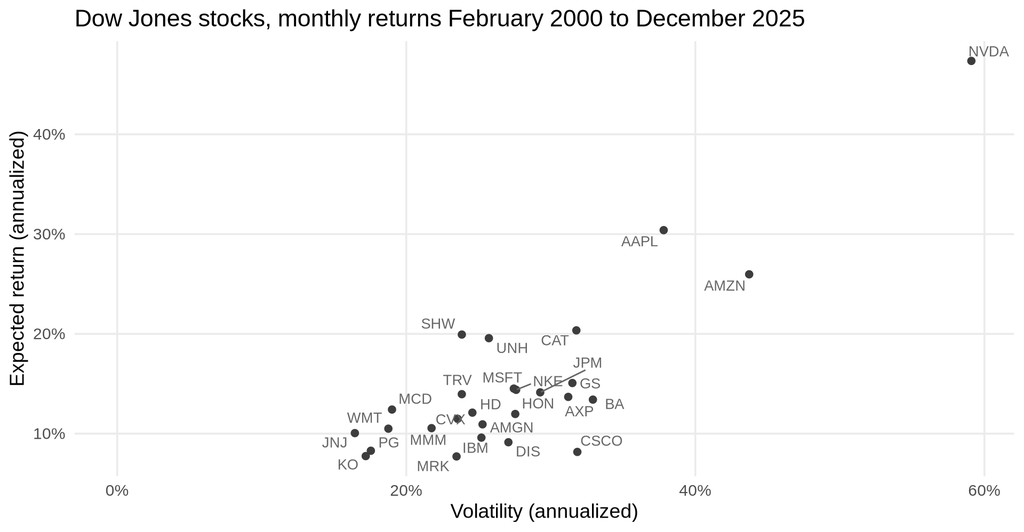

## Diversification

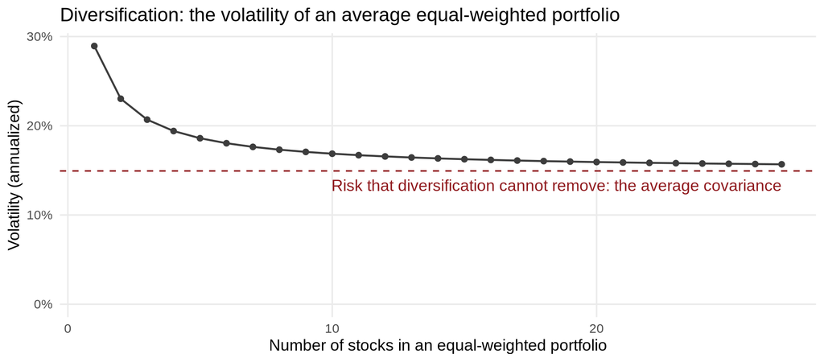

One stock: 28.9% volatility on average; 27 stocks: 15.7%. Variances diversify away, covariances do not

# Mean-variance optimization

## Mean-variance preferences

- Investors like expected return and dislike variance (Markowitz, 1952)
- With risk aversion $\gamma$, the certainty equivalent of a portfolio is

$$\text{CE}(\omega) = \omega'\mu - \frac{\gamma}{2}\,\omega'\Sigma\omega$$

- Exact for quadratic utility or normally distributed returns, an approximation otherwise
- Equivalent problem: the lowest variance for a given expected return. Exercise 2 asks you to show it

**The question of today:** which portfolios should a mean-variance investor hold?

## Whiteboard: the minimum-variance portfolio

$$\omega_\text{mvp} = \arg\min_\omega \ \omega'\Sigma\omega \quad \text{s.t.} \quad \iota'\omega = 1$$

$$\omega_\text{mvp} = \frac{\Sigma^{-1}\iota}{\iota'\Sigma^{-1}\iota} \qquad \text{Var}(r_\text{mvp}) = \frac{1}{\iota'\Sigma^{-1}\iota}$$

- It needs only $\Sigma$, no expected returns

Written out: Tidy Finance, [Proofs: minimum variance portfolio](https://www.tidy-finance.org/chapters/proofs.html#minimum-variance-portfolio)

## The minimum-variance portfolio of the Dow Jones 30

- R
- Python

```r
iota <- rep(1, ncol(sigma))
sigma_inv <- solve(sigma)

omega_mvp <- as.vector(sigma_inv %*% iota) / sum(sigma_inv %*% iota)
```

```python
iota = np.ones(len(mu))
sigma_inv = np.linalg.inv(sigma)

omega_mvp = sigma_inv @ iota / (iota @ sigma_inv @ iota)
```

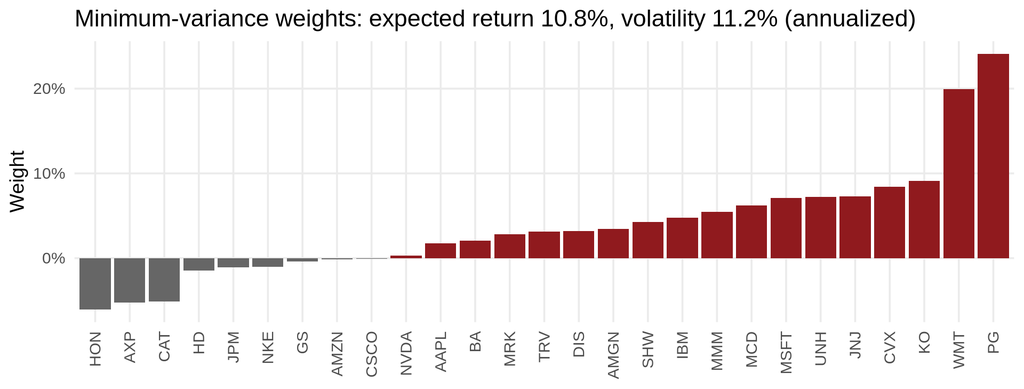

## Whiteboard: the efficient portfolio

$$\omega_\text{eff}(\bar\mu) = \arg\min_\omega \ \omega'\Sigma\omega \quad \text{s.t.} \quad \iota'\omega = 1, \ \ \omega'\mu = \bar\mu$$

With $C = \iota'\Sigma^{-1}\iota$, $D = \iota'\Sigma^{-1}\mu$ and $E = \mu'\Sigma^{-1}\mu$:

$$\omega_\text{eff}(\bar\mu) = \omega_\text{mvp} + \frac{\bar\mu - D/C}{E - D^2/C}\left(\Sigma^{-1}\mu - \frac{D}{C}\Sigma^{-1}\iota\right)$$

- **Two-fund separation:** every efficient portfolio is a combination of two efficient portfolios, e.g. $a\,\omega_\text{eff}(\bar\mu) + (1 - a)\,\omega_\text{mvp}$

Written out: Tidy Finance, [Proofs: efficient portfolio](https://www.tidy-finance.org/chapters/proofs.html#efficient-portfolio)

## The efficient frontier of the Dow Jones 30

- R
- Python

```r
C <- as.numeric(t(iota) %*% sigma_inv %*% iota)
D <- as.numeric(t(iota) %*% sigma_inv %*% mu)
E <- as.numeric(t(mu) %*% sigma_inv %*% mu)

# An efficient portfolio with three times the expected return of the mvp
mu_bar <- 3 * sum(omega_mvp * mu)
omega_eff <- omega_mvp + (mu_bar - D / C) / (E - D^2 / C) *
  as.vector(sigma_inv %*% mu - D / C * sigma_inv %*% iota)

efficient_frontier <- tibble(a = seq(-0.4, 1.9, by = 0.01)) |>
  mutate(
    omega = map(a, \(a) a * omega_eff + (1 - a) * omega_mvp),
    mu = map_dbl(omega, \(omega) sum(omega * mu)),
    sigma = map_dbl(omega, \(omega) sqrt(t(omega) %*% sigma %*% omega))
  )
```

```python
C = iota @ sigma_inv @ iota
D = iota @ sigma_inv @ mu
E = mu @ sigma_inv @ mu

# An efficient portfolio with three times the expected return of the mvp
mu_bar = 3 * omega_mvp @ mu
omega_eff = omega_mvp + (mu_bar - D / C) / (E - D**2 / C) * (
    sigma_inv @ mu - D / C * sigma_inv @ iota
)

a_grid = np.arange(-0.4, 1.91, 0.01)
omegas = [a * omega_eff + (1 - a) * omega_mvp for a in a_grid]
efficient_frontier = pl.DataFrame({
    "a": a_grid,
    "mu": [omega @ mu for omega in omegas],
    "sigma": [np.sqrt(omega @ sigma @ omega) for omega in omegas],
})
```

## The efficient frontier

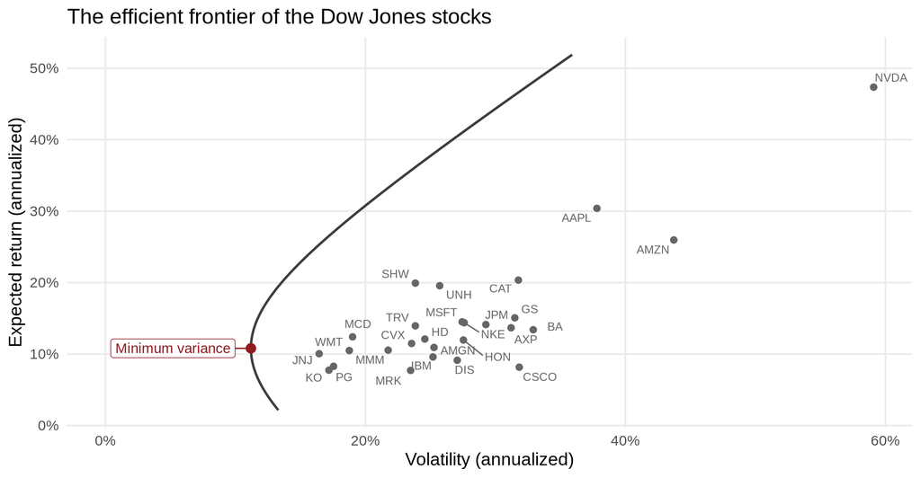

# Adding a risk-free asset

## Whiteboard: the tangency portfolio

- Invest $\omega$ in the risky assets and $1 - \iota'\omega$ at the risk-free rate $r_f$: expected return $r_f + \omega'(\mu - r_f\iota)$, variance $\omega'\Sigma\omega$

$$\min_\omega \ \omega'\Sigma\omega \quad \text{s.t.} \quad \omega'(\mu - r_f\iota) = \bar\mu - r_f$$

- The solution is proportional to $\Sigma^{-1}(\mu - r_f\iota)$. All risky wealth goes into the **tangency portfolio**

$$\omega_\text{tan} = \frac{\Sigma^{-1}(\mu - r_f\iota)}{\iota'\Sigma^{-1}(\mu - r_f\iota)}$$

- It has the highest Sharpe ratio $(\mu_\text{tan} - r_f)/\sigma_\text{tan}$ of all portfolios, the slope of the **capital market line** through $r_f$

## The tangency portfolio of the Dow Jones 30

- R
- Python

```r
# The average one-month T-bill rate over the sample
rf <- read_parquet("data/factors_ff3_monthly.parquet") |>
  filter(date >= start_date, date <= end_date) |>
  summarize(rf = mean(risk_free)) |>
  pull(rf)

omega_tan <- as.vector(sigma_inv %*% (mu - rf))
omega_tan <- omega_tan / sum(omega_tan)
```

```python
# The average one-month T-bill rate over the sample
rf = (
    pl.read_parquet("data/factors_ff3_monthly.parquet")
    .filter(
        pl.col("date") >= pl.lit(start_date).str.to_date(),
        pl.col("date") <= pl.lit(end_date).str.to_date(),
    )
    .get_column("risk_free")
    .mean()
)

omega_tan = sigma_inv @ (mu - rf)
omega_tan = omega_tan / omega_tan.sum()
```

The average T-bill rate is 1.9% a year. The tangency portfolio has an expected return of 31.1% at a volatility of 20.2%: a Sharpe ratio of 1.45 (annualized)

## The capital market line

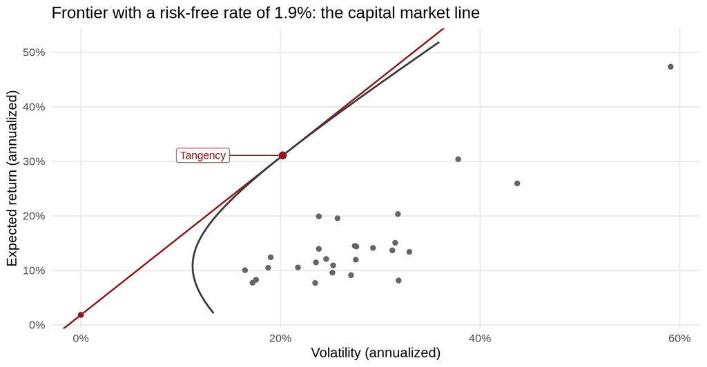

## Which point on the line?

- An investor with risk aversion $\gamma$ maximizes the certainty equivalent with a risk-free asset:

$$\omega^* = \frac{1}{\gamma}\,\Sigma^{-1}(\mu - r_f\iota)$$

- $\omega^*$ is proportional to $\omega_\text{tan}$: every mean-variance investor holds the **same risky portfolio**, mixed with the risk-free asset
- Risk aversion only decides the mix: the share in risky assets is $\iota'\omega^*$, the rest is borrowed or lent at $r_f$

**Two-fund separation (Tobin, 1958):** the tangency portfolio and the risk-free asset are all an investor needs

## The risk-free rate moves the tangency portfolio

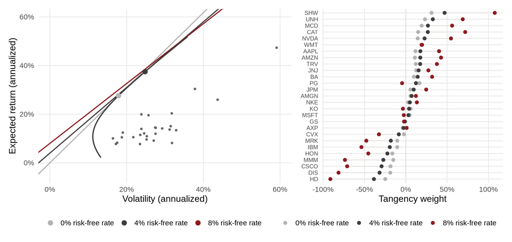

# What could go wrong?

## Would you hold this portfolio?

- The tangency portfolio promises 31.1% a year at 20.2% volatility, more than any single stock offers at that risk
- It shorts 10 of the 27 stocks; its largest position is 36.7% in SHW
- Compare it with how you split your $1

Every number rests on $\hat\mu$ and $\hat\Sigma$, estimated from the same 311 months. How much of it survives out of sample? Next lecture: **estimation uncertainty**